# Clustering with DBSCAN

Term 7, 2022

## The Dataset

Given a dataset that looks like this…

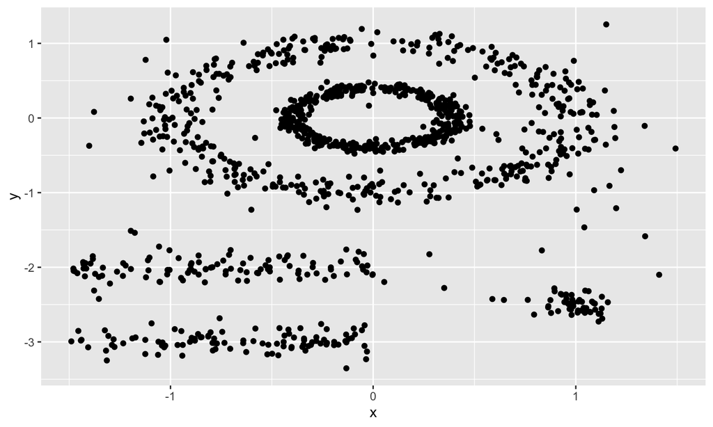

> How would you group these points?

## Let’s try clustering it!

Previously, we learned about 2 methods of clustering:

- K-means clustering
- Spectral clustering

Let’s take a look at how these methods would group the given dataset.

## K-means clustering plot

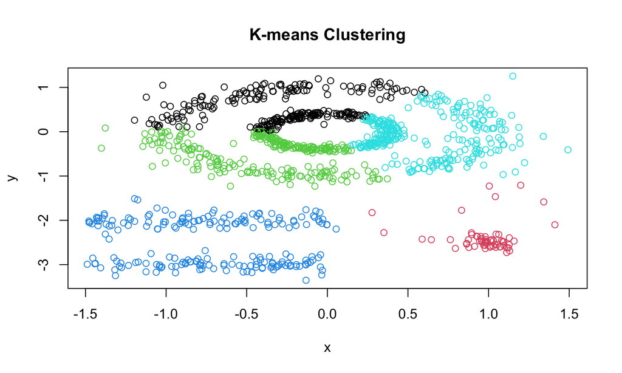

The clusters here aren’t so accurate. Like we learned in class, `kmeans()` usually finds clusters that are spherical and non-overlapping, hence it **doesn’t capture nested clusters** like the concentric ovals above.

## Spectral clustering plot

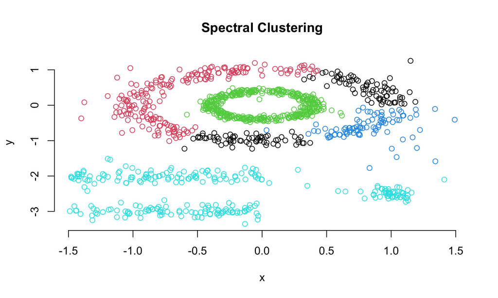

The spectral clustering output for automatically chosen parameters isn’t so accurate either…

## Spectral clustering with sigma = 500

By adjusting the sigma parameters, we can get a better output.

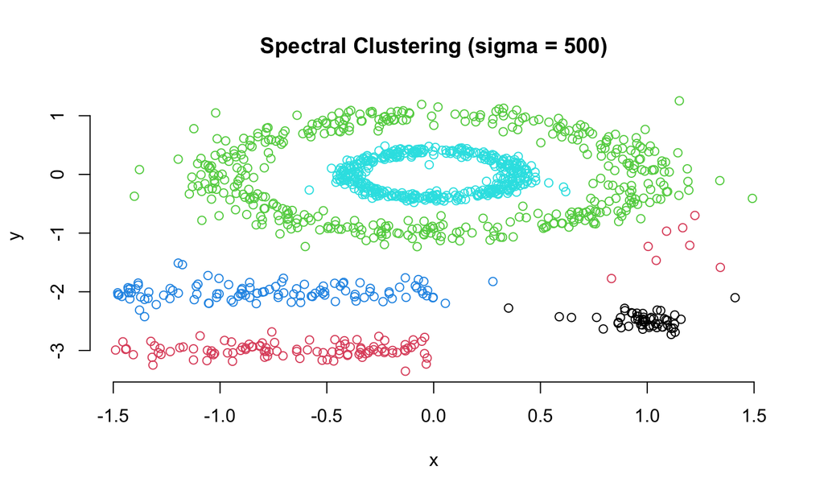

## Results

The results are much better, but not perfect.

Notice that…

- You have to adjust the sigma parameter to obtain the best clusters.
  - With multivariate datasets, you won’t be able to visualize your plots to check if the clusters look appropriate.
- The clusters **include noise** (ie. outliers).

*What if we told you there’s a better clustering method for this dataset?*

## DBSCAN clustering plot

Let’s take a look at how the DBSCAN method performs!

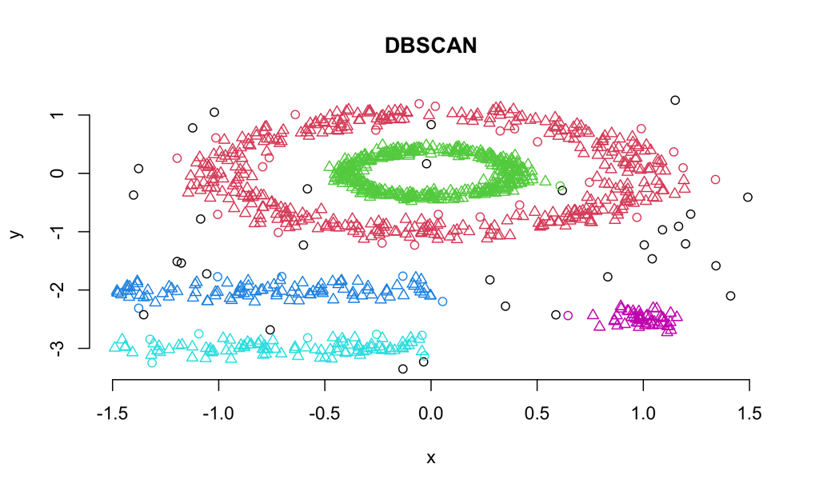

This method managed to not only **successfully group** each of the **visible clusters**, but also **identified the ‘noise points’** (that is, points that don’t belong to any cluster)!

## Clustering with DBSCAN

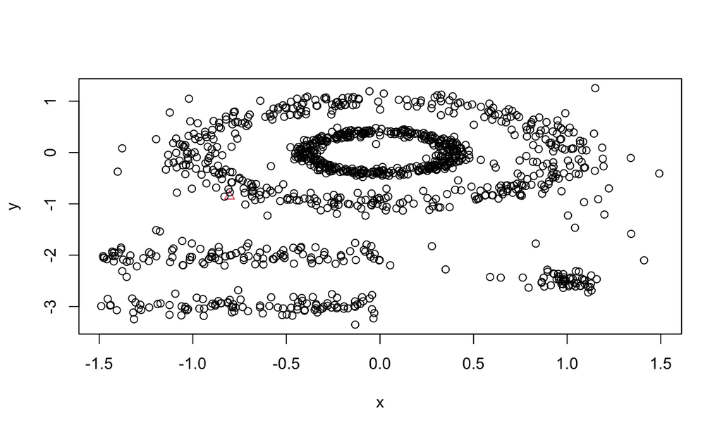

*Interested to find out how this works? Read our blog to find out more!* — Team 16